# Assignment 3: Verify the Claim: Poverty Change in Philadelphia

- Show All Code
- Hide All Code
- View Source

Author

Terry Xu

Published

September 24, 2026

## Article

[New Census figures on Philly neighborhoods show inequality, high numbers of whites living in poverty](https://whyy.org/articles/new-census-figures-on-philly-neighborhoods-show-inequality-high-numbers-of-whites-living-in-poverty/)

## Part 1: Reconstructing the Article’s Data

The article compares Philadelphia neighborhood poverty using the 2006–2010 and 2013–2017 ACS 5-year estimates. I use `survey = "acs5"` with `year = 2010` and `year = 2017` to retrieve those periods. The periods do not overlap, so they do not share collection years. For the change test, I use the standard approximation that the estimates from the two periods are independent.

I use table B17001: `B17001_002` counts people below the poverty level, and `B17001_001` counts people for whom poverty status is determined. Dividing these gives the poverty rate. I assume this measure corresponds to the article’s overall poverty measure. Because its neighborhood-to-tract definitions are unavailable, I compare Philadelphia census tracts rather than reconstructing its neighborhood totals. I match tracts by GEOID and assume matched tracts represent comparable areas; matching identifiers alone does not verify unchanged boundaries.

```r
poverty_10 <- get_acs(
  geography = "tract",
  state = "PA",
  county = "Philadelphia",
  variables = c(
    poor = "B17001_002",
    poverty_universe = "B17001_001"
  ),
  year = 2010,
  survey = "acs5",
  output = "wide"
)

poverty_17 <- get_acs(
  geography = "tract",
  state = "PA",
  county = "Philadelphia",
  variables = c(
    poor = "B17001_002",
    poverty_universe = "B17001_001"
  ),
  year = 2017,
  survey = "acs5",
  output = "wide"
)

dim(poverty_10)
```

```
[1] 384   6
```

```r
dim(poverty_17)
```

```
[1] 384   6
```

```r
poverty_10 <- poverty_10 %>%
  select(
    GEOID,
    poor_10E = poorE,
    poor_10M = poorM,
    universe_10E = poverty_universeE,
    universe_10M = poverty_universeM
  )

poverty_17 <- poverty_17 %>%
  select(
    GEOID,
    NAME,
    poor_17E = poorE,
    poor_17M = poorM,
    universe_17E = poverty_universeE,
    universe_17M = poverty_universeM
  )

poverty <- poverty_17 %>%
  left_join(poverty_10, by = "GEOID")

poverty %>%
  summarize(
    n_tracts = n(),
    no_2010_match = sum(is.na(poor_10E))
  )
```

```
# A tibble: 1 × 2
  n_tracts no_2010_match
     <int>         <int>
1      384             0
```

## Part 2: Testing Poverty Change

I first calculate the poverty rate and its margin of error for each tract in both periods. I also calculate the coefficient of variation (CV), which measures uncertainty relative to the size of the poverty-rate estimate. A lower CV means a more precise estimate.

```r
poverty <- poverty %>%
  mutate(
    poverty_rate_10 = poor_10E / universe_10E,
    poverty_moe_10 = moe_prop(
      poor_10E,
      universe_10E,
      poor_10M,
      universe_10M
    ),
    poverty_se_10 = poverty_moe_10 / 1.645,
    poverty_cv_10 = poverty_se_10 / poverty_rate_10 * 100,

    poverty_rate_17 = poor_17E / universe_17E,
    poverty_moe_17 = moe_prop(
      poor_17E,
      universe_17E,
      poor_17M,
      universe_17M
    ),
    poverty_se_17 = poverty_moe_17 / 1.645,
    poverty_cv_17 = poverty_se_17 / poverty_rate_17 * 100,

    reliability_17 = case_when(
      is.na(poverty_cv_17) ~ NA_character_,
      poverty_cv_17 < 12  ~ "Reliable",
      poverty_cv_17 <= 40 ~ "Somewhat reliable",
      TRUE                ~ "Unreliable"
    )
  )

poverty %>%
  summarize(
    n_tracts = n(),
    missing_2010_rate = sum(is.na(poverty_rate_10)),
    missing_2017_rate = sum(is.na(poverty_rate_17))
  )
```

```
# A tibble: 1 × 3
  n_tracts missing_2010_rate missing_2017_rate
     <int>             <int>             <int>
1      384                 7                 8
```

The original joined dataset contains 384 census tracts. Seven tracts are missing a usable poverty rate for 2006–2010, and eight are missing one for 2013–2017. Before comparing change, I inspect these tracts to understand why their rates are missing.

The following table shows the population counts used to calculate poverty rates for tracts with missing values. Most of these tracts have a poverty-status population of zero in at least one period, so dividing the number of people in poverty by the population would not produce a meaningful rate.

```r
poverty %>%
  filter(
    is.na(poverty_rate_10) | is.na(poverty_rate_17)
  ) %>%
  select(
    GEOID,
    NAME,
    poor_10E,
    universe_10E,
    poor_17E,
    universe_17E
  ) %>%
  print(n = Inf, width = Inf)
```

```
# A tibble: 8 × 6
  GEOID       NAME                                                 poor_10E
  <chr>       <chr>                                                   <dbl>
1 42101005000 Census Tract 50, Philadelphia County, Pennsylvania          0
2 42101980300 Census Tract 9803, Philadelphia County, Pennsylvania        0
3 42101980400 Census Tract 9804, Philadelphia County, Pennsylvania        0
4 42101980500 Census Tract 9805, Philadelphia County, Pennsylvania        0
5 42101980600 Census Tract 9806, Philadelphia County, Pennsylvania        9
6 42101980700 Census Tract 9807, Philadelphia County, Pennsylvania        0
7 42101980800 Census Tract 9808, Philadelphia County, Pennsylvania        0
8 42101980900 Census Tract 9809, Philadelphia County, Pennsylvania        0
  universe_10E poor_17E universe_17E
         <dbl>    <dbl>        <dbl>
1            0        0            0
2            0        0            0
3            0        0            0
4            0        0            0
5           92        0            0
6            0        0            0
7            0        0            0
8            0        0            0
```

These tracts include areas with little or no residential population, such as airport or industrial areas. I exclude tracts whose poverty-status population equals zero in either period because their poverty rates cannot be meaningfully calculated or compared.

```r
poverty_compare <- poverty %>%
  filter(
    universe_10E > 0,
    universe_17E > 0
  )

nrow(poverty_compare)
```

```
[1] 376
```

After removing tracts with zero poverty-status populations, 376 tracts remain. All later comparisons use these same 376 tracts.

For each remaining tract, I subtract the 2006–2010 poverty rate from the 2013–2017 poverty rate. Positive values indicate estimated increases, while negative values indicate estimated decreases. I then combine the margins of error from both periods and test whether each change is distinguishable from zero at 90% confidence.

```r
poverty_compare <- poverty_compare %>%
  mutate(
    change_pp = (poverty_rate_17 - poverty_rate_10) * 100,
    change_moe_pp = sqrt(
      poverty_moe_10^2 + poverty_moe_17^2
    ) * 100,
    lower = change_pp - change_moe_pp,
    upper = change_pp + change_moe_pp,
    change_result = case_when(
      is.na(lower) | is.na(upper) ~ "Cannot test",
      lower > 0 ~ "Detectable increase",
      upper < 0 ~ "Detectable decrease",
      TRUE ~ "No detectable change"
    )
  )

poverty_compare %>%
  count(change_result)
```

```
# A tibble: 3 × 2
  change_result            n
  <chr>                <int>
1 Detectable decrease     27
2 Detectable increase     36
3 No detectable change   313
```

The results show 36 tracts with a statistically detectable increase and 27 with a statistically detectable decrease. The other 313 tracts show no detectable change. This does not mean their poverty rates stayed exactly the same; it means the estimated changes were too small relative to their uncertainty to separate from zero.

```r
poverty_compare <- poverty_compare %>%
  mutate(
    reliability_10 = case_when(
      is.na(poverty_cv_10) ~ "Cannot assess",
      poverty_cv_10 < 12 ~ "Reliable",
      poverty_cv_10 <= 40 ~ "Somewhat reliable",
      TRUE ~ "Unreliable"
    ),
    reliability_17 = case_when(
      is.na(poverty_cv_17) ~ "Cannot assess",
      poverty_cv_17 < 12 ~ "Reliable",
      poverty_cv_17 <= 40 ~ "Somewhat reliable",
      TRUE ~ "Unreliable"
    )
  )
```

The next table evaluates the reliability of the poverty-rate estimates themselves. Following the Jurjevich et al. thresholds, estimates with a CV below 12% are reliable, estimates between 12% and 40% are somewhat reliable, and estimates above 40% are unreliable.

```r
reliability_counts_10 <- poverty_compare %>%
  count(reliability_10) %>%
  rename(
    reliability = reliability_10,
    tracts_2010 = n
  )

reliability_counts_17 <- poverty_compare %>%
  count(reliability_17) %>%
  rename(
    reliability = reliability_17,
    tracts_2017 = n
  )

reliability_table <- reliability_counts_10 %>%
  left_join(reliability_counts_17, by = "reliability") %>%
  mutate(
    symbol = case_when(
      reliability == "Reliable" ~ "✓",
      reliability == "Somewhat reliable" ~ "~",
      reliability == "Unreliable" ~ "!"
    )
  ) %>%
  select(symbol, reliability, tracts_2010, tracts_2017)

reliability_table %>%
  gt() %>%
  tab_header(
    title = "Reliability of Philadelphia Tract Poverty Rates",
    subtitle = "376 tracts included in the change comparison"
  ) %>%
  cols_label(
    symbol = "Symbol",
    reliability = "CV category",
    tracts_2010 = "2006–2010",
    tracts_2017 = "2013–2017"
  ) %>%
  tab_source_note(
    source_note = "Source: ACS 5-year estimates, table B17001. Jurjevich et al. (2018) thresholds: ✓ Reliable, CV < 12%; ~ Somewhat reliable, CV 12–40%; ! Unreliable, CV > 40%."
  )
```

Reliability of Philadelphia Tract Poverty Rates

376 tracts included in the change comparison

| Symbol | CV category | 2006–2010 | 2013–2017 |
| --- | --- | --- | --- |
| ✓ | Reliable | 11 | 22 |
| ~ | Somewhat reliable | 321 | 332 |
| ! | Unreliable | 44 | 22 |

Source: ACS 5-year estimates, table B17001. Jurjevich et al. (2018) thresholds: ✓ Reliable, CV < 12%; ~ Somewhat reliable, CV 12–40%; ! Unreliable, CV > 40%.

Most tract-level poverty rates fall into the somewhat reliable category. In 2006–2010, only 11 estimates were reliable, while 321 were somewhat reliable and 44 were unreliable. In 2013–2017, 22 were reliable, 332 were somewhat reliable, and 22 were unreliable. The later period therefore contains fewer unreliable estimates, although most estimates still have noticeable uncertainty.

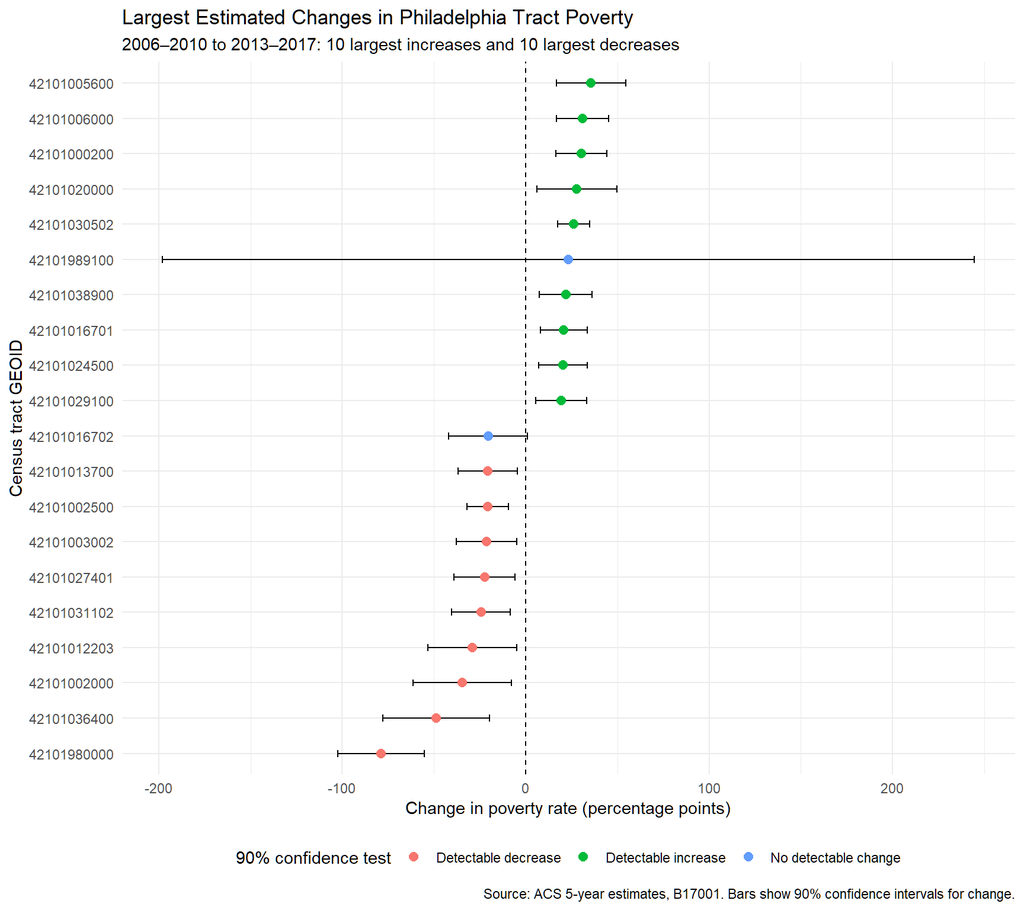

```r
largest_increases <- poverty_compare %>%
  arrange(desc(change_pp)) %>%
  head(10)

largest_decreases <- poverty_compare %>%
  arrange(change_pp) %>%
  head(10)

plot_tracts <- bind_rows(largest_increases, largest_decreases)

ggplot(
  plot_tracts,
  aes(x = reorder(GEOID, change_pp), y = change_pp)
) +
  geom_hline(yintercept = 0, linetype = "dashed") +
  geom_errorbar(
    aes(ymin = lower, ymax = upper),
    width = 0.2
  ) +
  geom_point(aes(color = change_result), size = 2.5) +
  coord_flip() +
  labs(
    title = "Largest Estimated Changes in Philadelphia Tract Poverty",
    subtitle = "2006–2010 to 2013–2017: 10 largest increases and 10 largest decreases",
    x = "Census tract GEOID",
    y = "Change in poverty rate (percentage points)",
    color = "90% confidence test",
    caption = "Source: ACS 5-year estimates, B17001. Bars show 90% confidence intervals for change."
  ) +
  theme_minimal() +
  theme(legend.position = "bottom")
```

This figure shows the ten largest estimated increases and ten largest estimated decreases, rather than all 376 tracts. Error bars that cross zero indicate changes that are not statistically detectable at 90% confidence.

Tract 9891 illustrates the importance of uncertainty. Its estimated poverty rate increased by 23.3 percentage points, but the change’s margin of error is about 221 percentage points. Its poverty-status population estimates were only 68 and 53, with margins of error larger than those estimates. The resulting approximate interval extends beyond possible changes, indicating that this comparison is too imprecise to support a conclusion about the direction of change.

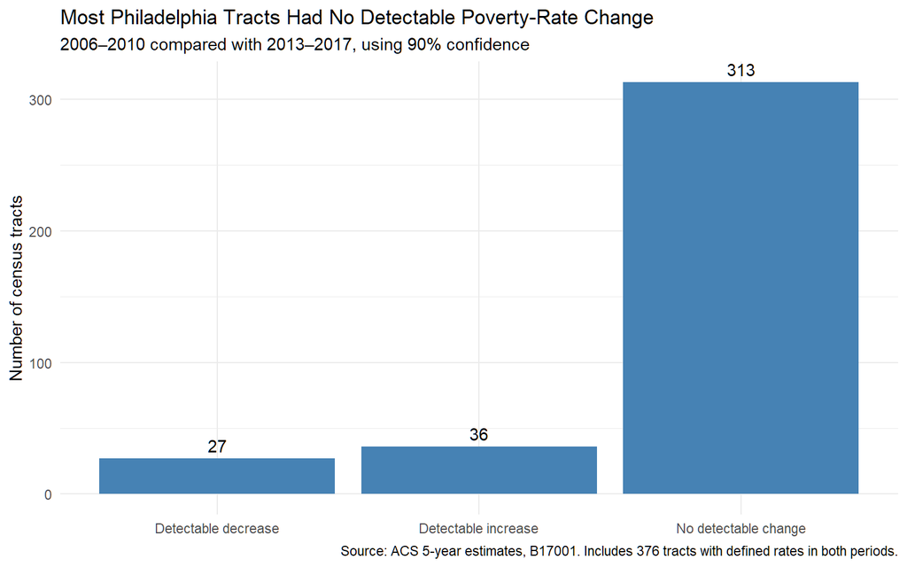

```r
change_counts <- poverty_compare %>%
  count(change_result)

ggplot(
  change_counts,
  aes(x = change_result, y = n)
) +
  geom_col(fill = "steelblue") +
  geom_text(aes(label = n), vjust = -0.5) +
  labs(
    title = "Most Philadelphia Tracts Had No Detectable Poverty-Rate Change",
    subtitle = "2006–2010 compared with 2013–2017, using 90% confidence",
    x = NULL,
    y = "Number of census tracts",
    caption = "Source: ACS 5-year estimates, B17001. Includes 376 tracts with defined rates in both periods."
  ) +
  theme_minimal()
```

### What the results show

Of the 376 tracts included in the comparison, 36 showed a statistically detectable increase in poverty and 27 showed a detectable decrease at 90% confidence. The remaining 313 tracts, or 83.2%, showed no statistically detectable change. This does not mean their poverty rates stayed exactly the same. It means the estimated changes were not large enough relative to their uncertainty to distinguish them from zero.

The reliability table also shows that most tract poverty rates were only somewhat reliable. In 2006–2010, 11 tracts were classified as reliable, 321 as somewhat reliable, and 44 as unreliable. In 2013–2017, those counts were 22, 332, and 22. These categories describe the precision of each period’s poverty rate; they do not directly determine whether the change between periods is statistically detectable.

Overall, the results show increases in some tracts and decreases in others. They do not establish what happened in the specific neighborhoods named in the article, because the article’s neighborhood-to-tract definitions are unavailable. The tract counts also do not measure the change in Philadelphia’s overall poverty rate, since tracts contain different numbers of people.

## Part 3: Which Claims Does the Evidence Support?

**Supported:** The article reports that poverty increased in some parts of Philadelphia. My tract-level analysis supports that broad pattern: 36 tracts showed statistically detectable increases between 2006–2010 and 2013–2017. However, 27 tracts showed detectable decreases, so the direction of change varied across the city. **Not supported by this analysis:** Treating every estimated increase as clear evidence that conditions worsened would overstate the findings. For example, Tract 9891 had an estimated increase of 23.3 percentage points, but its extremely large margin of error prevents a confident conclusion about the direction of change. Across all 376 comparable tracts, 313 changes were not statistically distinguishable from zero. This does not prove that poverty was unchanged in those places.

**Cannot be determined:** I cannot verify the article’s claim that Eastwick’s poverty rate rose from 12% to 26%, or that it had the largest neighborhood increase, because the article does not identify the tracts used to define each neighborhood. The same limitation prevents verification of Fairhill’s reported 61% poverty rate. My analysis also does not test the article’s claim about increasing poverty among white residents: the variables used here describe poverty across the full poverty-status population, not a specific racial group. Finally, these comparisons cannot establish the suggested causes of change, such as opioid use or migration. Those explanations would require additional evidence.

## Part 4: A More Defensible Account

Philadelphia’s poverty trends varied across census tracts between the 2006–2010 and 2013–2017 American Community Survey periods. Among 376 tracts with usable poverty rates in both periods, 36 showed increases and 27 showed decreases that were statistically detectable at 90% confidence. For the other 313, uncertainty was too large to establish a change. These results indicate worsening poverty in some areas and improvement in others, rather than a uniform trend. They also show why a large estimated increase should not automatically be treated as a clear deterioration. The article’s exact figures for neighborhoods such as Eastwick and Fairhill cannot be verified through this tract-level analysis without knowing how the neighborhood boundaries were defined.